# TIL ACT ChIP-seq

2022-10-19

## Once all packages are installed, the data can now be loaded in.

The data for diffbind consists of two main components which are contained within the peakset file: 1) the genomic location of the peaks called by MACS 2) the cleaned bam reads (which are used for library size normalization)

```r
TIL <- read.csv("diffbind/peakset_median.csv") #This "Median" peakset has duplicate samples removed (in excel). Some samples had both CD4 and CD8 run.
df<-as.data.frame(TIL)
median(df$TIL_Number)
```

```
## [1] 5.2e+10
```

## Assigning TIL High and Low to patient samples

```
## 1 CD4 Non-Responder 3.26e+10  1 macs
```

```
## 2 CD4 Non-Responder 2.04e+10  1 macs
```

```
## 3 CD4 Non-Responder 3.4e+10  1 macs
```

```
## 4 CD4 Responder 5.2e+10  1 macs
```

```
## 5 CD8 Responder 6.57e+10  1 macs
```

```
## 6 CD8 Non-Responder 7.3e+10  1 macs
```

```
## 7 CD8 Non-Responder 3.26e+10  1 macs
```

```
## 8 CD8 Responder 7.84e+10  1 macs
```

```
## 9 CD8 Non-Responder 2.04e+10  1 macs
```

```
## 10 CD8 Non-Responder 3.4e+10  1 macs
```

```
## 11 CD8 Non-Responder 7.3e+10  1 macs
```

```
## 12 CD4 Non-Responder 4.27e+10  2 macs
```

```
## 13 CD4 Non-Responder 8.58e+10  2 macs
```

```
## 14 CD4 Responder 3.11e+10  2 macs
```

```
## 15 CD4 Responder 3.88e+10  2 macs
```

```
## 16 CD8 Responder 7.4e+10  2 macs
```

```
## 17 CD8 Non-Responder 1.13e+11  2 macs
```

```
## 18 CD8 Responder 7.84e+10  2 macs
```

```
## 19 CD8 Non-Responder 2.04e+10  2 macs
```

```
## 20 CD8 Responder 8.09e+10  2 macs
```

```
## 21 CD8 Responder 5.21e+10  2 macs
```

```
## 22 CD8 Non-Responder 3.35e+10  2 macs
```

```
## 23 CD8 Non-Responder 8.58e+10  2 macs
```

```
## 24 CD8 Responder 3.11e+10  2 macs
```

```
## 25 CD8 Non-Responder 2.29e+10  2 macs
```

```
## 26 CD8 Responder 3.88e+10  2 macs
```

```
## 27 CD8 Responder 6.01e+10  2 macs
```

```
## 27 Samples, 113100 sites in matrix (213242 total):
##    ID Tissue        Factor Condition Replicate Intervals
## 1   1    CD4 Non-Responder  3.26e+10         1     53307
## 2   2    CD4 Non-Responder  2.04e+10         1     55217
## 3   3    CD4 Non-Responder   3.4e+10         1      6998
## 4   4    CD4     Responder   5.2e+10         1     53615
## 5   5    CD8     Responder  6.57e+10         1     35523
## 6   6    CD8 Non-Responder   7.3e+10         1     56327
## 7   7    CD8 Non-Responder  3.26e+10         1     38807
## 8   8    CD8     Responder  7.84e+10         1     67138
## 9   9    CD8 Non-Responder  2.04e+10         1     45708
## 10 10    CD8 Non-Responder   3.4e+10         1     69730
## 11 11    CD8 Non-Responder   7.3e+10         1     49049
## 12 12    CD4 Non-Responder  4.27e+10         2     46079
## 13 13    CD4 Non-Responder  8.58e+10         2     31206
## 14 14    CD4     Responder  3.11e+10         2     44216
## 15 15    CD4     Responder  3.88e+10         2     38194
## 16 16    CD8     Responder   7.4e+10         2     61782
## 17 17    CD8 Non-Responder  1.13e+11         2     29380
## 18 18    CD8     Responder  7.84e+10         2     53127
## 19 19    CD8 Non-Responder  2.04e+10         2     28725
## 20 20    CD8     Responder  8.09e+10         2     47201
## 21 21    CD8     Responder  5.21e+10         2     76561
## 22 22    CD8 Non-Responder  3.35e+10         2     68783
## 23 23    CD8 Non-Responder  8.58e+10         2     63124
## 24 24    CD8     Responder  3.11e+10         2     17373
## 25 25    CD8 Non-Responder  2.29e+10         2     67256
## 26 26    CD8     Responder  3.88e+10         2     46036
## 27 27    CD8     Responder  6.01e+10         2     63775
```

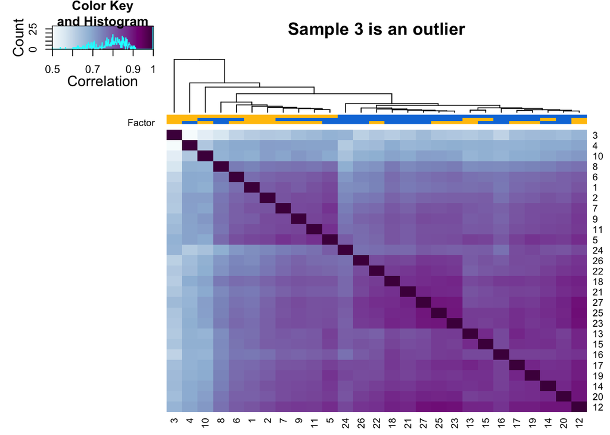

```
##    SampleID Tissue        Factor Condition Treatment Replicate
## 1         1    CD4 Non-Responder  3.26e+10       Low         1
## 2         2    CD4 Non-Responder  2.04e+10       Low         1
## 4         4    CD4     Responder  5.20e+10      High         1
## 5         5    CD8     Responder  6.57e+10      High         1
## 6         6    CD8 Non-Responder  7.30e+10      High         1
## 7         7    CD8 Non-Responder  3.26e+10       Low         1
## 8         8    CD8     Responder  7.84e+10      High         1
## 9         9    CD8 Non-Responder  2.04e+10       Low         1
## 10       10    CD8 Non-Responder  3.40e+10       Low         1
## 11       11    CD8 Non-Responder  7.30e+10      High         1
## 12       12    CD4 Non-Responder  4.27e+10       Low         2
## 13       13    CD4 Non-Responder  8.58e+10      High         2
## 14       14    CD4     Responder  3.11e+10       Low         2
## 15       15    CD4     Responder  3.88e+10       Low         2
```

[output cut: 147 more lines]

## Creating DBA object for only CD8+ Samples

```r
CD8_samples<-samples
CD8_samples_filt<-dplyr::filter(CD8_samples, Tissue %in% c("CD8"))
CD8_samples_final<-CD8_samples_filt[-c(7,10),] #These two samples are removed because they are duplicate patient samples
chip_CD8<- dba(sampleSheet = CD8_samples_final)
```

```
## 5 CD8 Responder 6.57e+10 High 1 macs
```

```
## 6 CD8 Non-Responder 7.3e+10 High 1 macs
```

```
## 7 CD8 Non-Responder 3.26e+10 Low 1 macs
```

```
## 8 CD8 Responder 7.84e+10 High 1 macs
```

```
## 9 CD8 Non-Responder 2.04e+10 Low 1 macs
```

```
## 10 CD8 Non-Responder 3.4e+10 Low 1 macs
```

```
## 16 CD8 Responder 7.4e+10 High 2 macs
```

```
## 17 CD8 Non-Responder 1.13e+11 High 2 macs
```

```
## 19 CD8 Non-Responder 2.04e+10 Low 2 macs
```

```
## 20 CD8 Responder 8.09e+10 High 2 macs
```

```
## 21 CD8 Responder 5.21e+10 High 2 macs
```

```
## 22 CD8 Non-Responder 3.35e+10 Low 2 macs
```

```
## 23 CD8 Non-Responder 8.58e+10 High 2 macs
```

```
## 24 CD8 Responder 3.11e+10 Low 2 macs
```

```
## 25 CD8 Non-Responder 2.29e+10 Low 2 macs
```

```
## 26 CD8 Responder 3.88e+10 Low 2 macs
```

```
## 27 CD8 Responder 6.01e+10 High 2 macs
```

##Reads in peaks must be counted for each sample bScaleControl is used to correct for possibility that the control file is larger than a sample file bSubControl is used to subtract reads that appear in the control sample (aka background reads)

```r
CD8_samples_final_count <- dba.count(chip_CD8, minOverlap = 2, bScaleControl = TRUE, bSubControl = TRUE, bParallel = TRUE)
```

```
## Computing summits...
```

```
## Re-centering peaks...
```

##Normalize the reads Normalizing reads in diffbind is not as simple as it is in DESeq2. For ChIP and ATAC experiments, one cannot always simply assume that the libraries will be the same size (this can be influenced by the ChIP/ATAC efficiency). Furthermore, there are conditions in which the library may fundamentally differ between conditions (for instance, when looking at HDACi-treated samples vs control). Therefore, one must decide to use either the full library size or the reads in peaks (RIP). It is probably best to evaluate both and look at the resultant MA-plots to determine which to use.

```r
chip_CD8_norm <- dba.normalize(CD8_samples_final_count, method = DBA_DESEQ2, normalize = DBA_NORM_NATIVE, library= DBA_LIBSIZE_FULL)
```

##Identify differentially bound (or in this case acetylated) sites Different methods can be used (i.e., DESeq2 or EDGER). bBlacklist removes blacklisted regions and bGreylist removes regions that are overepresented in the control files.

```r
CD8_Results <- dba.analyze(chip_CD8_norm, method = DBA_DESEQ2, bBlacklist = TRUE, bGreylist=TRUE, bParallel = TRUE, design= "~Treatment + Replicate") #this contrast controls for group bias
```

```
## Applying Blacklist/Greylists...
```

```
## Genome detected: Hsapiens.UCSC.hg38
```

```
## Applying blacklist...
```

```
## Removed: 24 of 98154 intervals.
```

```
## Counting control reads for greylist...
```

```
## Building greylist: dedup_group1/13_2586Moff_Pooled_Input_i93_trimmed.bam.sorted.bam.filtered.bam.marked.bam
```

```
## coverage: 1096336 bp (0.04%)
```

```
## Building greylist: dedup_group2/17_2938Moff_Pool_16_samples_Input_hs_i88_trimmed.bam.sorted.bam.filtered.bam.marked.bam
```

```
## coverage: 2701312 bp (0.09%)
```

```
## Input: 138 ranges, 1096336 bases
```

```
## Input: 888 ranges, 2701312 bases
```

```
## Master greylist: 947 ranges, 3027600 bases
```

```
## Removed: 559 of 98130 intervals.
```

```
## Re-normalizing...
```

```
## Removed 583 (of 98154) consensus peaks.
```

```
## Setting design...
```

```
## Computing results names...
```

```
## Setting default contrast(s)...
```

```
## Analyzing...
```

##Creating reports from the contrasts I had to use bFlip to reverse the order of TIL high compared with TIL low. I like to export all of the results and then filter them manually.

```r
CD8_Report<-dba.report(CD8_Results, th=1, contrast = 1, bFlip = TRUE)
filtered_1<- CD8_Report[((CD8_Report$Fold < -0.58 & CD8_Report$FDR < 0.1) | (CD8_Report$Fold > 0.58 & CD8_Report$FDR < 0.1)),]
visualize_dataset_CD8 <- dba.report(CD8_Results, contrast=1, th=1, bFlip = TRUE, bCount=TRUE)
```

##PCA plot I like to first create a PCA plot to determine if any differences exist between the two groups being compared. Here, I wanted to see if there were differences between the acetylation between TIL high and TIL low patients.

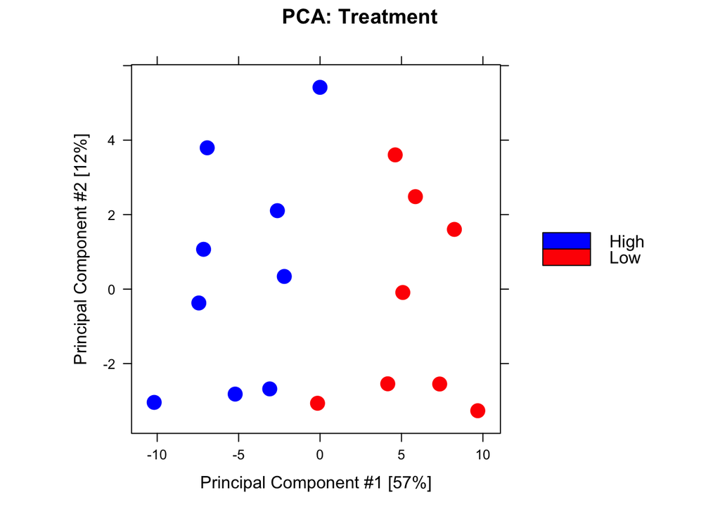

```r
pca <- dba.plotPCA(CD8_Results, attributes = DBA_TREATMENT, vColors = c("blue", "red"), contrast=1, th=.1)
```

```r
pdf("PCA.pdf", height = 8, width = 8)
print(pca)
dev.off()
```

##Peak annotation I determined that the best way to annotate the panH3ac ChIP peaks was to use chipenrich, which obstensibly is for pathway analysis of chip-seq data. However, it does have a annotation function built in which I have co-opted here to annotate the otherwise very difficult to annotate these peaks (these peaks are difficult to annotate as they can appear as both broad and narrow, at distal/proximal sites to the TSS, and at the gene body).

```r
result_test=broadenrich(peaks = as.data.frame(CD8_Report), genome = 'hg38', genesets = 'kegg_pathway', locusdef = "nearest_gene", qc_plots = TRUE, out_name = NULL, n_cores = 8)
```

```
## Reading peaks from data.frame...
```

```
## Assigning peaks to genes with assign_peak_segments(...) ..
```

```
## Calculating peak overlaps with gene loci..
```

```
## Test: Broad-Enrich
```

```
## Genesets: KEGG Pathways
```

```
## Running tests..
```

```r
results_test.ce = result_test$results
print(results_test.ce[1:35,1:5])
```

```
##     Geneset.Type Geneset.ID
## 1  KEGG Pathways   hsa04510
## 2  KEGG Pathways   hsa04360
## 3  KEGG Pathways   hsa04810
## 4  KEGG Pathways   hsa05200
## 5  KEGG Pathways   hsa04010
## 6  KEGG Pathways   hsa05414
## 7  KEGG Pathways   hsa04020
## 8  KEGG Pathways   hsa05410
## 9  KEGG Pathways   hsa04512
## 10 KEGG Pathways   hsa05412
## 11 KEGG Pathways   hsa04340
## 12 KEGG Pathways   hsa04912
## 13 KEGG Pathways   hsa05217
## 14 KEGG Pathways   hsa04144
```

[output cut: 93 more lines]

```r
gobp <- result_test$results[1:10,1:5]
results_test.ce = result_test$peaks
peaks<-results_test.ce[,1:11]

peaks$merged <- str_c(peaks$chr,";", peaks$peak_start)
CD8_peaks <- as.data.frame(visualize_dataset_CD8)
CD8_peaks$merged <- str_c(CD8_peaks$seqnames,";", CD8_peaks$start)

merged_datasets <- merge(peaks, CD8_peaks , by="merged")
filtered_merged_datasets <- merged_datasets[((merged_datasets$Fold < -0.58 & merged_datasets$FDR < 0.1) | (merged_datasets$Fold > 0.58 & merged_datasets$FDR < 0.1)) ,]
write.csv(merged_datasets,"full_CD8_anno.csv", row.names = TRUE)
write.csv(filtered_merged_datasets,"filtered_CD8_anno.csv", row.names = TRUE)
```

##Heatmap of the DACs

[figure not shown]

```r
heatmap_CD8 <- heatmap.2(as.matrix(filtered_merged_datasets[24:ncol(filtered_merged_datasets)]), cexRow = 0.6, cexCol = 0.6, scale="row", trace = "none", margins = c(7,5), key = FALSE, labRow = filtered_merged_datasets$gene_symbol, Rowv = TRUE, Colv = TRUE,
          , col=rev(brewer.pal(11,"RdBu")), ColSideColors = c("orange", "orange", "orange", "orange", "orange", "orange",
                                                              "orange", "orange", "light green", "orange", "light green", "light green", "light green",
                                                              "light green", "light green", "light green", "light green"))
```

```r
pdf("Heatmap", width = 8, height = 8)
print(heatmap_CD8)
```

[output not shown]

[output cut: 132 more lines]

[output not shown]

```r
dev.off()
```

##Volcano of the CD8+ DACs

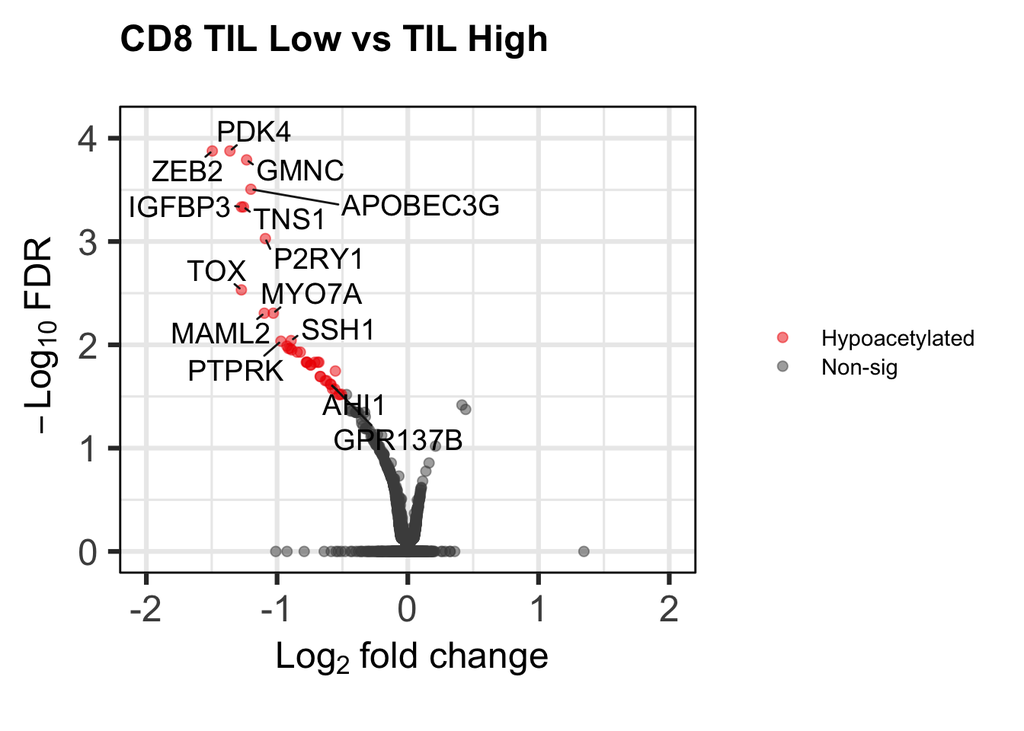

```r
keyvals <- ifelse(
  merged_datasets$Fold < -0.5 & merged_datasets$FDR < 0.1, 'red2',
  ifelse(merged_datasets$Fold > 0.50 & merged_datasets$FDR < 0.1, 'red2',
         'grey30'))
keyvals[is.na(keyvals)] <- 'grey30k'
names(keyvals)[keyvals == 'red2'] <- 'Hypoacetylated'
names(keyvals)[keyvals == 'grey30'] <- 'Non-sig'
names(keyvals)[keyvals == 'royalblue'] <- 'Hyperacetylated'


volcano_plot <- EnhancedVolcano(merged_datasets,
                lab = merged_datasets$gene_symbol,
                x = "Fold",
                y = "FDR", ylab = bquote(~-Log[10] ~ FDR),
                title = "CD8 TIL Low vs TIL High",
                subtitle = "", subtitleLabSize = 0.01,
                cutoffLineType = 'blank',
                colCustom = keyvals, legendPosition = 'right',
                xlim = c(-2,2), ylim = c(0, 4.1),
                legendLabSize = 11, legendIconSize = 2, caption = "", captionLabSize = 0.0000001,
                pCutoff = 0.1,FCcutoff = 0.58, labSize = 5, drawConnectors = TRUE, arrowheads=FALSE, max.overlaps = 25,
                border = 'full', borderWidth = 0.5, borderColour = 'black')
volcano_plot
```

```r
pdf("ChIP CD8 Volcano Plot.pdf", width = 8, height = 8)
print(volcano_plot)
dev.off()
```

##Dot plots of key genes Based on results from ssGSEA (which were calculated using python), DACs are suggestive of altered CD8+ activation. Therefore, I focused on the DACs that are known to be involved in T-cell activation

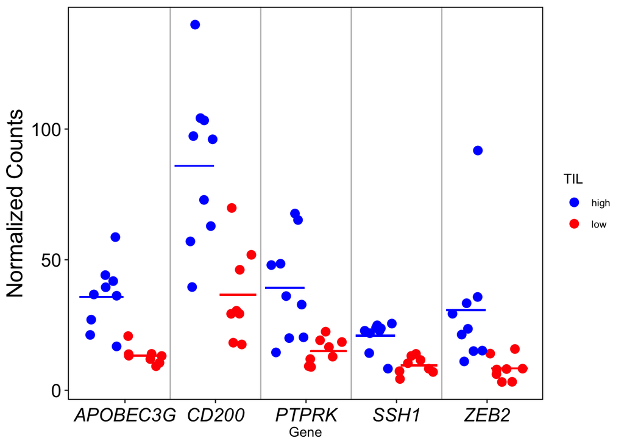

```r
df_list <- filtered_merged_datasets %>% filter((gene_symbol == "APOBEC3G" | gene_symbol == "SSH1" | gene_symbol == "CD200" | gene_symbol == "ZEB2" | gene_symbol == "PTPRK"))
df_list <- df_list[-3,]

df_list_long <- df_list %>% pivot_longer(cols=c(24:40),
                                       names_to='Sample',
                                       values_to='Counts')

df_list_long <- df_list_long %>%
  mutate(TIL = case_when(Sample == "X5" ~ "high", Sample == "X6" ~ "high", Sample == "X7" ~ "low", Sample == "X8" ~ "high", Sample == "X9" ~ "low", Sample == "X10" ~ "low",
                        Sample == "X16" ~ "high", Sample == "X17" ~ "high",  Sample == "X19" ~ "low", Sample == "X20" ~ "high",
                         Sample == "X21" ~ "high", Sample == "X22" ~ "low", Sample == "X23" ~ "high", Sample == "X24" ~ "low",
                         Sample == "X25" ~ "low", Sample == "X26" ~ "low", Sample == "X27" ~ "high"))


SSH1 <- df_list_long %>% dplyr::filter(gene_symbol == "SSH1")
SSH1_mean <- SSH1 %>%
  group_by(TIL) %>%
  summarise(mean_val = mean(Counts))


ZEB2 <- df_list_long %>% dplyr::filter(gene_symbol == "ZEB2")
ZEB2_mean <- ZEB2 %>%
  group_by(TIL) %>%
  summarise(mean_val = mean(Counts))

APOBEC3G <- df_list_long %>% dplyr::filter(gene_symbol == "APOBEC3G")
APOBEC3G_mean <- APOBEC3G %>%
  group_by(TIL) %>%
  summarise(mean_val = mean(Counts))

PTPRK<- df_list_long %>% dplyr::filter(gene_symbol == "PTPRK")
PTPRK_mean <- PTPRK %>%
  group_by(TIL) %>%
  summarise(mean_val = mean(Counts))

CD200<- df_list_long %>% dplyr::filter(gene_symbol == "CD200")
CD200_mean <- CD200 %>%
  group_by(TIL) %>%
  summarise(mean_val = mean(Counts))



dotplot_CD8 <- ggplot(df_list_long, aes(gene_symbol, Counts)) + geom_point(aes(color = TIL), position = position_jitterdodge(dodge.width = 0.9), size = 3.0) +
  scale_color_manual(values = c("blue", "red")) +
  theme_bw() +
  theme(panel.grid.major = element_blank(), panel.grid.minor = element_blank())+
  theme(axis.text.x = element_text(vjust = 0.5, face = "italic", size = 15, color = "black")) + labs(x = "Gene", y = "Normalized Counts") +
  theme(axis.text.y = element_text(size = 15, color = "black")) + theme(legend.text = element_text(size = 8)) + theme(axis.title.y = element_text(size = 18)) +
  geom_vline(xintercept = c(1.5, 2.5, 3.5, 4.5), color= "grey") +
  theme(panel.border = element_rect(fill=NA, colour = "black", size=.75)) +
  geom_segment(aes(x = .5,xend = .98, y=35.8, yend = 35.8), color = "blue", size = .65) + geom_segment(aes(x = 1.05,xend = 1.45, y=13.3, yend = 13.3), color = "red", size = 0.65) +
  geom_segment(aes(x = 1.55,xend = 1.98, y=85.9, yend = 85.9), color = "blue", size = .65) + geom_segment(aes(x = 2.05,xend = 2.45, y=36.6, yend = 36.6), color = "red", size = 0.65) +
  geom_segment(aes(x = 2.55,xend = 2.98, y=39.2, yend = 39.2), color = "blue", size = .65) + geom_segment(aes(x = 3.05,xend = 3.45, y=15.0, yend = 15.0), color = "red", size = 0.65) +
  geom_segment(aes(x = 3.55,xend = 3.98, y=20.9, yend = 20.9), color = "blue", size = .65) + geom_segment(aes(x = 4.05,xend = 4.45, y=9.52, yend = 9.52), color = "red", size = 0.65) +
  geom_segment(aes(x = 4.55,xend = 4.98, y=30.7, yend = 30.7), color = "blue", size = .65) + geom_segment(aes(x = 5.05,xend = 5.45, y=8.37, yend = 8.37), color = "red", size = 0.65)
dotplot_CD8
```

```r
pdf("CD8 Target Genes Dotplot.pdf", width=8, height=8)
print(dotplot_CD8)
dev.off()
```

##Graphing acetylation score Clearly acetylation at genes associated with T-cell activation is associated with TIL high individuals, however, I wanted to also determine if this acetylation was also associated with overall survival. Therefore, I calculated an “acetylation score” for each sample and then plotted this with overall survival.

```r
#Making an enrichment score for the CD8 DAGs

sorting <- filtered_merged_datasets

#Selecting only the needed columns
sorting <- sorting %>% dplyr::select(gene_symbol, X5, X6, X7, X8, X9, X10, X16, X17,
                                     X19, X20, X21, X22, X23, X24, X25, X26, X27)
avg <- sorting %>% rowwise() %>% mutate(average = mean(c(X5, X6, X7, X8, X9, X10, X16, X17,
                                                         X19, X20, X21, X22, X23, X24, X25, X26, X27)))

sum(avg$average) #1094.008
```

```
## [1] 1094.008
```

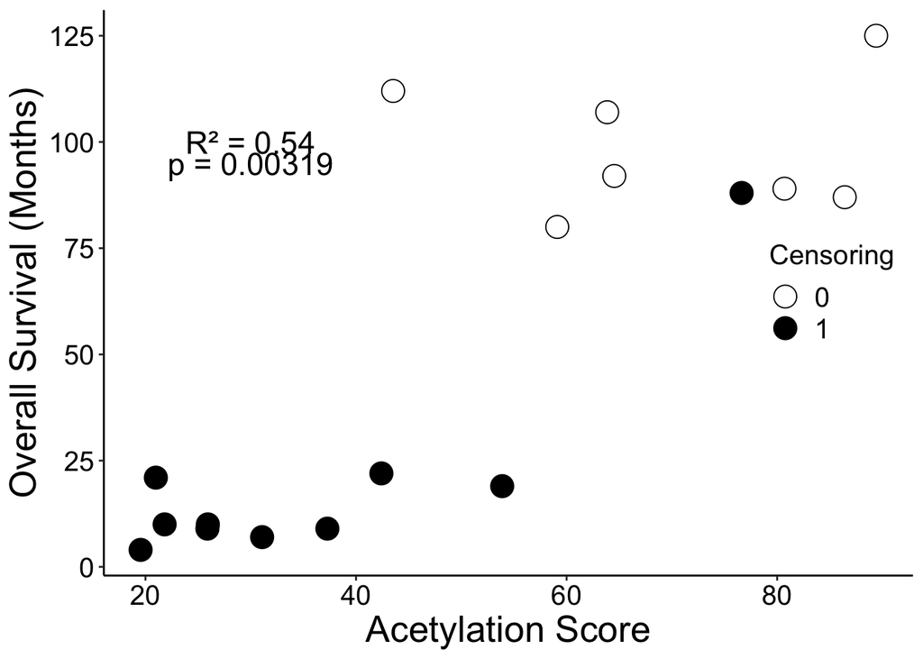

```r
weight1 <- avg %>% rowwise() %>% mutate(weight = (average/1094.008))
weight1 <- as.data.frame(weight1)
weight = weight1$weight

scale2 <- function(x, na.rm = FALSE) (x * weight)
computed <- weight1 %>% mutate_at(c("X5", "X6", "X7", "X8", "X9", "X10",
                                     "X16", "X17", "X19", "X20", "X21", "X22", "X23", "X24",
                                     "X25", "X26", "X27"), scale2)
computed <- computed[,-1]

t_set <- t(computed)
t_set <- as.data.frame(t_set)
sample_sums <- t_set %>% mutate(sample_sum = rowSums(t_set))

sample_sums <- sample_sums[-c(18,19),]

#Adding in the TIL number data
TIL_num <- CD8_samples_filt$Condition
TIL_num <- as.data.frame(TIL_num)
TIL_num <- format(TIL_num$TIL_num, scientific = FALSE)
TIL_num <- TIL_num[-c(7, 10)]
sample_sums %<>% mutate(TIL_num = TIL_num)
sample_sums$TIL_num <- as.numeric(sample_sums$TIL_num)

#Adding in the OS data
OS <- c(88, 19, 22, 112, 10, 4, 125, 107, 7,
        87, 80, 9, 89, 10, 9, 21, 92)


#Adding in the censored data
cens <- c(1, 1, 1, 0, 1, 1, 0, 0, 1, 0, 0, 1, 0, 1, 1, 1, 0)
sample_sums <- sample_sums %>% mutate(cens = cens)

coxph_model_SCORE_OS = coxph(Surv(OS, cens) ~ sample_sum, data = sample_sums)


pt1 <- ggplot(sample_sums, aes(x=sample_sum, y=OS, shape=as.factor(cens))) +
  geom_point(size=5.5)  +
  theme_classic() +
  labs(shape = "Censoring") +
  xlab(label = "Acetylation Score") +
  ylab(label = "Overall Survival (Months)") +
  scale_shape_discrete(name = "Censoring", labels = c("Censored", "Not Censored")) +
  scale_shape_manual(values=c(1, 19)) +
  annotate("text", size = 6, x = 30, y = 100, label = paste("R² =", round(summary(coxph_model_SCORE_OS)$rsq[1], 2))) +
  annotate("text", size = 6, x = 30, y = 95, label = paste("p =", round(summary(coxph_model_SCORE_OS)$waldtest[3], 5))) +
  theme(axis.text = element_text(size = 15, color = "black"), axis.title = element_text(size = 20),
        legend.text = element_text(size = 15), legend.title = element_text(size = 15),
        legend.position = c(0.90, 0.5))
pt1
```

```r
pdf("OSvsAcetylation Score.pdf", width = 8, height = 8)
print(pt1)
dev.off()
```